# Desktop

### 8. Visualize how popularity of genres has changed over the years - 10 marks

Note that you need to use the **percent of number of releases in a year** as a parameter of popularity of a genre

Hint 1: You need to reach to a data frame where the release year is the index and the genre is the column names (one cell shows the number of release in a year in one genre) or vice versa. (Drop unnecessary column if there are any)

Hint 2: Find the total number of movies release in a year(use item dataset to get count of movies released in a particular year, store that value in a new column as 'total'). Now divide the value of each genre in that year by total to get percentage number of release in a particular year. `(df.div(df['total'], axis= 0) * 100)`

Once that is achieved, you can either use univariate plots or can use the heatmap to visualise all the changes over the years in one go.

Hint 3: Use groupby on the relevant column and use sum() on the same to find out the number of releases in a year/genre.

```python
genre_by_year = item.groupby("release year").sum()
genre_by_year = genre_by_year.drop(columns="movie id")
genre_by_year
```

| release year | unknown | Action | Adventure | Animation | Childrens | Comedy | Crime | Documentary | Drama | Fantasy | Film-Noir | Horror | Musical | Mystery | Romance | Sci-Fi | Thriller | War | Western |
| --- | --- | --- | --- | --- | --- | --- | --- | --- | --- | --- | --- | --- | --- | --- | --- | --- | --- | --- | --- |
| 1922 | 0 | 0 | 0 | 0 | 0 | 0 | 0 | 0 | 0 | 0 | 0 | 1 | 0 | 0 | 0 | 0 | 0 | 0 | 0 |
| 1926 | 0 | 0 | 0 | 0 | 0 | 0 | 0 | 0 | 1 | 0 | 0 | 0 | 0 | 0 | 0 | 0 | 0 | 0 | 0 |
| 1930 | 0 | 0 | 0 | 0 | 0 | 0 | 0 | 0 | 1 | 0 | 0 | 0 | 0 | 0 | 0 | 0 | 0 | 0 | 0 |
| 1931 | 0 | 0 | 0 | 0 | 0 | 0 | 1 | 0 | 0 | 0 | 1 | 0 | 0 | 0 | 0 | 0 | 1 | 0 | 0 |
| 1932 | 0 | 0 | 0 | 0 | 0 | 0 | 0 | 0 | 0 | 0 | 0 | 0 | 0 | 0 | 1 | 0 | 0 | 1 | 0 |
| ... | ... | ... | ... | ... | ... | ... | ... | ... | ... | ... | ... | ... | ... | ... | ... | ... | ... | ... | ... |
| 1994 | 0 | 30 | 13 | 4 | 15 | 82 | 8 | 9 | 97 | 3 | 0 | 8 | 2 | 2 | 35 | 7 | 25 | 7 | 6 |
| 1995 | 0 | 40 | 22 | 6 | 21 | 63 | 11 | 5 | 89 | 3 | 1 | 14 | 3 | 5 | 37 | 15 | 39 | 5 | 2 |
| 1996 | 0 | 44 | 24 | 9 | 21 | 108 | 21 | 18 | 170 | 6 | 1 | 11 | 9 | 6 | 38 | 15 | 47 | 9 | 2 |
| 1997 | 0 | 46 | 20 | 3 | 22 | 87 | 30 | 6 | 113 | 4 | 2 | 8 | 5 | 18 | 51 | 13 | 54 | 14 | 0 |
| 1998 | 0 | 12 | 3 | 0 | 1 | 13 | 7 | 3 | 33 | 1 | 2 | 4 | 1 | 3 | 11 | 5 | 18 | 0 | 0 |

71 rows × 19 columns

```python
movie_count = (
    item.groupby("release year")["movie id"]
    .count()
    .reset_index()
    .rename(columns={"movie id": "Total"})
    .set_index("release year")
)
genre_by_year.join(movie_count)
genre_by_year = genre_by_year.join(movie_count)
genre_by_year = (
    (genre_by_year.div(genre_by_year["Total"], axis=0) * 100).drop("Total", axis=1).T
)
genre_by_year
```

| release year | 1922 | 1926 | 1930 | 1931 | 1932 | 1933 | 1934 | 1935 | 1936 | 1937 | ... | 1989 | 1990 | 1991 | 1992 | 1993 | 1994 | 1995 | 1996 | 1997 | 1998 |
| --- | --- | --- | --- | --- | --- | --- | --- | --- | --- | --- | --- | --- | --- | --- | --- | --- | --- | --- | --- | --- | --- |
| unknown | 0.0 | 0.0 | 0.0 | 0.0 | 0.0 | 0.0 | 0.0 | 0.0 | 0.0 | 0.0 | ... | 0.000000 | 0.000000 | 0.000000 | 0.000000 | 0.000000 | 0.000000 | 0.000000 | 0.000000 | 0.000000 | 0.000000 |
| Action | 0.0 | 0.0 | 0.0 | 0.0 | 0.0 | 0.0 | 0.0 | 0.0 | 0.0 | 0.0 | ... | 40.000000 | 29.166667 | 9.090909 | 21.621622 | 15.873016 | 14.018692 | 18.264840 | 12.394366 | 16.083916 | 18.461538 |
| Adventure | 0.0 | 0.0 | 0.0 | 0.0 | 0.0 | 0.0 | 0.0 | 0.0 | 0.0 | 0.0 | ... | 26.666667 | 4.166667 | 4.545455 | 2.702703 | 7.142857 | 6.074766 | 10.045662 | 6.760563 | 6.993007 | 4.615385 |
| Animation | 0.0 | 0.0 | 0.0 | 0.0 | 0.0 | 0.0 | 0.0 | 0.0 | 0.0 | 25.0 | ... | 0.000000 | 0.000000 | 4.545455 | 5.405405 | 0.793651 | 1.869159 | 2.739726 | 2.535211 | 1.048951 | 0.000000 |
| Childrens | 0.0 | 0.0 | 0.0 | 0.0 | 0.0 | 0.0 | 0.0 | 0.0 | 0.0 | 25.0 | ... | 0.000000 | 4.166667 | 4.545455 | 2.702703 | 4.761905 | 7.009346 | 9.589041 | 5.915493 | 7.692308 | 1.538462 |
| Comedy | 0.0 | 0.0 | 0.0 | 0.0 | 0.0 | 50.0 | 50.0 | 50.0 | 50.0 | 50.0 | ... | 20.000000 | 25.000000 | 27.272727 | 32.432432 | 30.952381 | 38.317757 | 28.767123 | 30.422535 | 30.419580 | 20.000000 |
| Crime | 0.0 | 0.0 | 0.0 | 100.0 | 0.0 | 0.0 | 0.0 | 0.0 | 0.0 | 0.0 | ... | 6.666667 | 12.500000 | 0.000000 | 13.513514 | 5.555556 | 3.738318 | 5.022831 | 5.915493 | 10.489510 | 10.769231 |
| Documentary | 0.0 | 0.0 | 0.0 | 0.0 | 0.0 | 0.0 | 0.0 | 0.0 | 0.0 | 0.0 | ... | 0.000000 | 8.333333 | 4.545455 | 0.000000 | 3.174603 | 4.205607 | 2.283105 | 5.070423 | 2.097902 | 4.615385 |
| Drama | 0.0 | 100.0 | 100.0 | 0.0 | 0.0 | 0.0 | 25.0 | 0.0 | 50.0 | 25.0 | ... | 53.333333 | 50.000000 | 50.000000 | 37.837838 | 50.793651 | 45.327103 | 40.639269 | 47.887324 | 39.510490 | 50.769231 |
| Fantasy | 0.0 | 0.0 | 0.0 | 0.0 | 0.0 | 0.0 | 0.0 | 0.0 | 0.0 | 0.0 | ... | 0.000000 | 0.000000 | 4.545455 | 0.000000 | 0.000000 | 1.401869 | 1.369863 | 1.690141 | 1.398601 | 1.538462 |
| Film-Noir | 0.0 | 0.0 | 0.0 | 100.0 | 0.0 | 0.0 | 0.0 | 0.0 | 0.0 | 0.0 | ... | 0.000000 | 4.166667 | 0.000000 | 0.000000 | 0.793651 | 0.000000 | 0.456621 | 0.281690 | 0.699301 | 3.076923 |
| Horror | 100.0 | 0.0 | 0.0 | 0.0 | 0.0 | 0.0 | 0.0 | 25.0 | 0.0 | 0.0 | ... | 0.000000 | 4.166667 | 4.545455 | 16.216216 | 3.968254 | 3.738318 | 6.392694 | 3.098592 | 2.797203 | 6.153846 |
| Musical | 0.0 | 0.0 | 0.0 | 0.0 | 0.0 | 0.0 | 25.0 | 25.0 | 0.0 | 75.0 | ... | 0.000000 | 0.000000 | 9.090909 | 2.702703 | 1.587302 | 0.934579 | 1.369863 | 2.535211 | 1.748252 | 1.538462 |
| Mystery | 0.0 | 0.0 | 0.0 | 0.0 | 0.0 | 0.0 | 25.0 | 0.0 | 0.0 | 0.0 | ... | 0.000000 | 0.000000 | 0.000000 | 2.702703 | 4.761905 | 0.934579 | 2.283105 | 1.690141 | 6.293706 | 4.615385 |
| Romance | 0.0 | 0.0 | 0.0 | 0.0 | 100.0 | 50.0 | 25.0 | 25.0 | 0.0 | 50.0 | ... | 6.666667 | 16.666667 | 0.000000 | 18.918919 | 12.698413 | 16.355140 | 16.894977 | 10.704225 | 17.832168 | 16.923077 |
| Sci-Fi | 0.0 | 0.0 | 0.0 | 0.0 | 0.0 | 0.0 | 0.0 | 0.0 | 0.0 | 0.0 | ... | 13.333333 | 0.000000 | 18.181818 | 8.108108 | 6.349206 | 3.271028 | 6.849315 | 4.225352 | 4.545455 | 7.692308 |
| Thriller | 0.0 | 0.0 | 0.0 | 100.0 | 0.0 | 0.0 | 0.0 | 25.0 | 0.0 | 0.0 | ... | 13.333333 | 16.666667 | 13.636364 | 13.513514 | 13.492063 | 11.682243 | 17.808219 | 13.239437 | 18.881119 | 27.692308 |
| War | 0.0 | 0.0 | 0.0 | 0.0 | 100.0 | 50.0 | 0.0 | 0.0 | 0.0 | 0.0 | ... | 13.333333 | 0.000000 | 4.545455 | 5.405405 | 3.174603 | 3.271028 | 2.283105 | 2.535211 | 4.895105 | 0.000000 |
| Western | 0.0 | 0.0 | 0.0 | 0.0 | 0.0 | 0.0 | 0.0 | 0.0 | 0.0 | 0.0 | ... | 0.000000 | 8.333333 | 0.000000 | 2.702703 | 1.587302 | 2.803738 | 0.913242 | 0.563380 | 0.000000 | 0.000000 |

19 rows × 71 columns

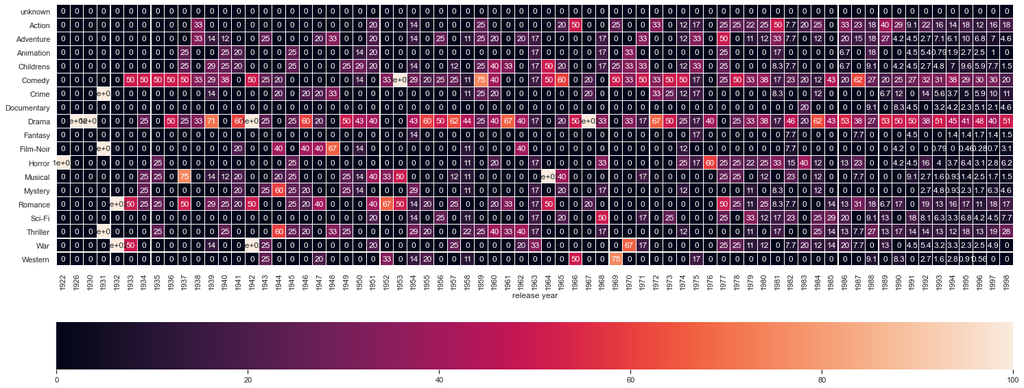

```python
plt.figure(figsize=(25, 10))
sns.heatmap(
    genre_by_year, annot=True, linewidths=0.10, cbar_kws={"orientation": "horizontal"}
)
plt.show()
```

**Insights:** It looks like drama and comedy have been pretty steady over the years and Thriller and romance for some reason lost traction from 1967 to 1976 which is odd. Fantasy movies are at the bottom and Doccumentary films didnt get any views from 1922 to 1983 which is also strange. I guess people didnt want to learn about the past.

### 9. Find the top 25 movies in terms of average ratings for movies that have been rated more than 100 times - 10 marks

Hints :

1. Find the count of ratings and average ratings for every movie.
2. Slice the movies which have ratings more than 100.
3. Sort values according to average rating such that movie which highest rating is on top.
4. Select top 25 movies.
5. You will have to use the .merge() function to get the movie titles.

Note: This question will need you to research about groupby and apply your findings. You can find more on groupby on https://realpython.com/pandas-groupby/.

```python
movie = data.groupby('movie id')['rating'].agg(['count','mean'])
movie.head()
```

| movie id | count | mean |
| --- | --- | --- |
| 1 | 452 | 3.878319 |
| 2 | 131 | 3.206107 |
| 3 | 90 | 3.033333 |
| 4 | 209 | 3.550239 |
| 5 | 86 | 3.302326 |

```python
movie = movie[movie['count'] > 100]

movie.head()
```

| movie id | count | mean |
| --- | --- | --- |
| 1 | 452 | 3.878319 |
| 2 | 131 | 3.206107 |
| 4 | 209 | 3.550239 |
| 7 | 392 | 3.798469 |
| 8 | 219 | 3.995434 |

```python
movie = movie.sort_values(by='mean',ascending=False)

movie.head()
```

| movie id | count | mean |
| --- | --- | --- |
| 408 | 112 | 4.491071 |
| 318 | 298 | 4.466443 |
| 169 | 118 | 4.466102 |
| 483 | 243 | 4.456790 |
| 64 | 283 | 4.445230 |

```python
movie.merge(item[["movie id", "movie title"]], on="movie id", how="left").head(25)
```

|  | movie id | count | mean | movie title |
| --- | --- | --- | --- | --- |
| 0 | 408 | 112 | 4.491071 | Close Shave, A |
| 1 | 318 | 298 | 4.466443 | Schindler's List |
| 2 | 169 | 118 | 4.466102 | Wrong Trousers, The |
| 3 | 483 | 243 | 4.456790 | Casablanca |
| 4 | 64 | 283 | 4.445230 | Shawshank Redemption, The |
| 5 | 603 | 209 | 4.387560 | Rear Window |
| 6 | 12 | 267 | 4.385768 | Usual Suspects, The |
| 7 | 50 | 583 | 4.358491 | Star Wars |
| 8 | 178 | 125 | 4.344000 | 12 Angry Men |
| 9 | 134 | 198 | 4.292929 | Citizen Kane |
| 10 | 427 | 219 | 4.292237 | To Kill a Mockingbird |
| 11 | 357 | 264 | 4.291667 | One Flew Over the Cuckoo's Nest |
| 12 | 98 | 390 | 4.289744 | Silence of the Lambs, The |
| 13 | 480 | 179 | 4.284916 | North by Northwest |
| 14 | 127 | 413 | 4.283293 | Godfather, The |
| 15 | 285 | 162 | 4.265432 | Secrets & Lies |
| 16 | 272 | 198 | 4.262626 | Good Will Hunting |
| 17 | 657 | 131 | 4.259542 | Manchurian Candidate, The |
| 18 | 474 | 194 | 4.252577 | Dr. Strangelove or: How I Learned to Stop Worr... |
| 19 | 174 | 420 | 4.252381 | Raiders of the Lost Ark |
| 20 | 479 | 179 | 4.251397 | Vertigo |
| 21 | 313 | 350 | 4.245714 | Titanic |
| 22 | 511 | 173 | 4.231214 | Lawrence of Arabia |
| 23 | 484 | 138 | 4.210145 | Maltese Falcon, The |
| 24 | 172 | 367 | 4.204360 | Empire Strikes Back, The |

### 10. Check for the validity of the below statements with respect to the data provided - 10 marks

- Men watch more drama than women
- Women watch more Sci-Fi than men
- Men watch more Romance than women

**compare the percentages**

**Please pay attention to what should be the denominator while calculating percentages**

1. Merge all the datasets
2. There is no need to conduct statistical tests around this. Just **compare the percentages** and comment on the validity of the above statements.
3. you might want ot use the .sum(), .div() function here.
4. Use number of ratings to validate the numbers. For example, if out of 4000 ratings received by women, 3000 are for drama, we will assume that 75% of the women watch drama.

```python
ud = user.merge(data,on='user id',how='inner')
df = item.merge(ud,on='movie id',how='inner')
df.head()
```

|  | movie id | movie title | release date | unknown | Action | Adventure | Animation | Childrens | Comedy | Crime | ... | War | Western | release year | user id | age | gender | occupation | zip code | rating | timestamp |
| --- | --- | --- | --- | --- | --- | --- | --- | --- | --- | --- | --- | --- | --- | --- | --- | --- | --- | --- | --- | --- | --- |
| 0 | 1 | Toy Story | 01-Jan-1995 | 0 | 0 | 0 | 1 | 1 | 1 | 0 | ... | 0 | 0 | 1995 | 1 | 24 | M | technician | 85711 | 5 | 874965758 |
| 1 | 1 | Toy Story | 01-Jan-1995 | 0 | 0 | 0 | 1 | 1 | 1 | 0 | ... | 0 | 0 | 1995 | 2 | 53 | F | other | 94043 | 4 | 888550871 |
| 2 | 1 | Toy Story | 01-Jan-1995 | 0 | 0 | 0 | 1 | 1 | 1 | 0 | ... | 0 | 0 | 1995 | 5 | 33 | F | other | 15213 | 4 | 875635748 |
| 3 | 1 | Toy Story | 01-Jan-1995 | 0 | 0 | 0 | 1 | 1 | 1 | 0 | ... | 0 | 0 | 1995 | 6 | 42 | M | executive | 98101 | 4 | 883599478 |
| 4 | 1 | Toy Story | 01-Jan-1995 | 0 | 0 | 0 | 1 | 1 | 1 | 0 | ... | 0 | 0 | 1995 | 10 | 53 | M | lawyer | 90703 | 4 | 877888877 |

5 rows × 30 columns

```python
Genre_by_gender = df.groupby('gender').sum().loc[:,'Action':'Western']
Genre_by_gender['total'] = df['gender'].value_counts()
Genre_by_gender
```

| gender | Action | Adventure | Animation | Childrens | Comedy | Crime | Documentary | Drama | Fantasy | Film-Noir | Horror | Musical | Mystery | Romance | Sci-Fi | Thriller | War | Western | total |
| --- | --- | --- | --- | --- | --- | --- | --- | --- | --- | --- | --- | --- | --- | --- | --- | --- | --- | --- | --- |
| F | 5442 | 3141 | 995 | 2232 | 8068 | 1794 | 187 | 11008 | 363 | 385 | 1197 | 1442 | 1314 | 5858 | 2629 | 5086 | 2189 | 371 | 25738 |
| M | 20147 | 10612 | 2610 | 4950 | 21764 | 6261 | 571 | 28887 | 989 | 1348 | 4120 | 3512 | 3931 | 13603 | 10101 | 16786 | 7209 | 1483 | 74252 |

```python
Genre_by_gender = Genre_by_gender.div(Genre_by_gender.total, axis= 0) * 100
Genre_by_gender
```

| gender | Action | Adventure | Animation | Childrens | Comedy | Crime | Documentary | Drama | Fantasy | Film-Noir | Horror | Musical | Mystery | Romance | Sci-Fi | Thriller | War | Western | total |
| --- | --- | --- | --- | --- | --- | --- | --- | --- | --- | --- | --- | --- | --- | --- | --- | --- | --- | --- | --- |
| F | 21.143834 | 12.203745 | 3.865879 | 8.672002 | 31.346647 | 6.970239 | 0.726552 | 42.769446 | 1.410366 | 1.495843 | 4.650711 | 5.602611 | 5.105292 | 22.760121 | 10.214469 | 19.760665 | 8.504934 | 1.441448 | 100.0 |
| M | 27.133276 | 14.291871 | 3.515057 | 6.666487 | 29.310995 | 8.432096 | 0.769003 | 38.904003 | 1.331951 | 1.815439 | 5.548672 | 4.729839 | 5.294133 | 18.320045 | 13.603674 | 22.606798 | 9.708829 | 1.997253 | 100.0 |

**Conclusion:**

Women watch more Sci-Fi than men?

False: 13.60 % or 10101 males watch sci-fi and 10.21% or 2629 females watch sci-fi